# ISA 591 Final Project Part 1: EDA

Harrison Cradduck, Nick Berry

2025-10-03

# 1 Introduction

In this project, our ultimate goal is to predict whether a loan applicant will default on their loan based on historical loan and applicant data. Loan default is a significant risk for financial institutions, and accurately predicting the likelihood of default can help lenders make more informed decisions about granting loans. By applying data mining techniques, we will develop predictive models that help to assess an applicant’s risk of default based on various factors.

# 2 Data Dictionary

| Variable | Description |
| --- | --- |
| loan_default | Whether the loan has defaulted. Values: “Yes”, “No”. |
| loan_amnt | The listed amount of the loan applied for by the borrower. |
| term | The number of payments on the loan (36 or 60 months). |
| int_rate | Interest rate on the loan. |
| installment | The monthly payment owed by the borrower if the loan originates. |
| grade | Loan grade assigned by Lending Club. |
| sub_grade | Loan subgrade assigned by Lending Club. |
| emp_title | Job title supplied by the borrower. |
| emp_length | Employment length in years (“< 1 year” to “10+ years”). |
| home_ownership | Home ownership status: RENT, OWN, MORTGAGE, OTHER. |
| annual_inc | Self-reported annual income of the borrower. |
| verification_status | Whether income was verified: Verified, Not Verified, etc. |
| issue_d | The month when the loan was funded. |
| purpose | Category provided by the borrower for the loan request. |
| title | Loan title provided by the borrower. |
| dti | Debt-to-income ratio. |
| earliest_cr_line | Month of the borrower’s earliest reported credit line. |
| open_acc | Number of open credit lines. |
| pub_rec | Number of derogatory public records. |
| revol_bal | Total revolving balance. |
| revol_util | Revolving line utilization rate (credit used / total credit). |
| total_acc | Total number of credit lines in the borrower’s credit file. |
| initial_list_status | Initial listing status of the loan: f (whole) or w (fractional). |
| application_type | Type of application: individual, joint, direct pay. |
| mort_acc | Number of mortgage accounts. |
| pub_rec_bankruptcies | Number of public record bankruptcies. |
| address | Borrower’s address. |
| delinq_2yrs | Number of 30+ days delinquency incidents in past 2 years. |
| fico_range_low | Lower end of FICO score range. |
| fico_range_high | Upper end of FICO score range. |
| inq_last_6mths | Number of credit inquiries in the past 6 months. |
| mths_since_last_delinq | Months since last delinquency (NA if never). |
| last_credit_pull_d | Most recent date credit was pulled. |
| acc_now_delinq | Number of accounts currently delinquent. |
| hardship_flag | Whether borrower is under hardship plan (Y/N). |
| debt_settlement_flag | Whether borrower is in a debt settlement program (Y/N). |

# 3 Data Loading

```r
# read in .csv file and convert all strings to factors
df <- read.csv("train.csv", stringsAsFactors = TRUE)
head(df)
```

|  | loan_default | loan_amnt | term | int_rate | installment | grade | sub_grade | emp_title | emp_length | home_ownership | annual_inc | verification_status | issue_d | purpose | title | dti | earliest_cr_line | open_acc | pub_rec | revol_bal | revol_util | total_acc | initial_list_status | application_type | mort_acc | pub_rec_bankruptcies | address | delinq_2yrs | fico_range_low | … |
| --- | --- | --- | --- | --- | --- | --- | --- | --- | --- | --- | --- | --- | --- | --- | --- | --- | --- | --- | --- | --- | --- | --- | --- | --- | --- | --- | --- | --- | --- | --- |
| 1 | No | 15175 | 36 months | 16.55 | 537.64 | D | D2 | Maintenance | 9 years | MORTGAGE | 33000 | Source Verified | Oct-2015 | debt_consolidation | Debt consolidation | 23.56 | Sep-2006 | 11 | 0 | 11376 | 46.1 | 24 | f | INDIVIDUAL | 2 | 0 | 359 Miles Neck\nEast Fernando, ME 22690 | 4 | 680 | … |
| 2 | Yes | 7500 | 36 months | 11.99 | 249.08 | B | B3 | Professional | 6 years | RENT | 40000 | Not Verified | Dec-2013 | credit_card | Credit Fund | 29.49 | Sep-2002 | 11 | 0 | 7113 | 56.5 | 23 | w | INDIVIDUAL | 0 | 0 | 630 James Corners\nNew Frederick, NV 93700 | 0 | 680 | … |
| 3 | Yes | 12000 | 60 months | 24.50 | 348.71 | F | F3 | Purchasing | 4 years | MORTGAGE | 70000 | Source Verified | Jan-2014 | debt_consolidation | Credit | 18.50 | Feb-1997 | 12 | 0 | 11699 | 83.6 | 48 | w | INDIVIDUAL | 6 | 0 | 2082 Williams Green Apt. 298\nWest Ashley, WI 30723 | 0 | 665 | … |
| 4 | No | 12000 | 36 months | 13.05 | 404.62 | B | B5 | Wells Fargo | 2 years | RENT | 85000 | Verified | Aug-2013 | debt_consolidation | Credit Card Payoff | 33.36 | May-1994 | 21 | 0 | 21133 | 58.7 | 35 | f | INDIVIDUAL | 2 | 0 | 375 Quinn Gateway Suite 800\nPort Cesarview, SD 22690 | 1 | 665 | … |
| 5 | No | 18200 | 36 months | 7.26 | 564.13 | A | A4 | Merchandise Manager | 8 years | MORTGAGE | 78000 | Source Verified | May-2015 | debt_consolidation | Debt consolidation | 14.28 | Aug-1995 | 9 | 0 | 11304 | 62.8 | 22 | w | INDIVIDUAL | 3 | 0 | Unit 2532 Box 6782\nDPO AP 05113 | 0 | 695 | … |
| 6 | No | 7000 | 36 months | 11.99 | 232.47 | C | C1 | Sales Manager | < 1 year | MORTGAGE | 69000 | Source Verified | Apr-2016 | debt_consolidation | Debt consolidation | 18.63 | Sep-2001 | 12 | 1 | 12056 | 44.7 | 37 | w | INDIVIDUAL | 0 | 0 | USCGC Velazquez\nFPO AP 48052 | 0 | 670 | … |

# 4 Exploratory Data Analysis

The goal of this phase is to explore the dataset, understand its structure, detect any patterns or anomalies, and clean the data to prepare it for model building. Proper EDA and data preprocessing are essential for enhancing the quality of the dataset and ensuring the models can learn effectively from the data.

## 4.1 Data Overview

### 4.1.1 Summary Statistics

```r
# skim the data
skimr::skim(df)
```

Data summary

| Name | df |
| --- | --- |
| Number of rows | 237730 |
| Number of columns | 36 |
| _______________________ |  |
| Column type frequency: |  |
| factor | 18 |
| numeric | 18 |
| ________________________ |  |
| Group variables | None |

**Variable type: factor**

| skim_variable | n_missing | complete_rate | ordered | n_unique | top_counts |
| --- | --- | --- | --- | --- | --- |
| loan_default | 0 | 1 | FALSE | 2 | No: 191095, Yes: 46635 |
| term | 0 | 1 | FALSE | 2 | 36: 181516, 60: 56214 |
| grade | 0 | 1 | FALSE | 7 | B: 69716, C: 63862, A: 38634, D: 37824 |
| sub_grade | 0 | 1 | FALSE | 35 | B3: 16009, B4: 15345, C1: 14286, C2: 13672 |
| emp_title | 0 | 1 | FALSE | 112646 | emp: 13871, Tea: 2607, Man: 2541, Sup: 1118 |
| emp_length | 0 | 1 | FALSE | 12 | 10+: 75581, 2 y: 21531, < 1: 19068, 3 y: 19024 |
| home_ownership | 0 | 1 | FALSE | 5 | MOR: 118808, REN: 96106, OWN: 22723, OTH: 67 |
| verification_status | 0 | 1 | FALSE | 3 | Ver: 83840, Sou: 78761, Not: 75129 |
| issue_d | 0 | 1 | FALSE | 115 | Oct: 8855, Jul: 7635, Jan: 7038, Dec: 6440 |
| purpose | 0 | 1 | FALSE | 14 | deb: 140874, cre: 49826, hom: 14394, oth: 12661 |
| title | 0 | 1 | FALSE | 31659 | Deb: 91432, Cre: 30958, Hom: 9112, Oth: 7706 |
| earliest_cr_line | 0 | 1 | FALSE | 659 | Oct: 1807, Aug: 1779, Aug: 1740, Oct: 1701 |
| initial_list_status | 0 | 1 | FALSE | 2 | f: 142760, w: 94970 |
| application_type | 0 | 1 | FALSE | 3 | IND: 237305, JOI: 254, DIR: 171 |
| address | 0 | 1 | FALSE | 236733 | USN: 7, 458: 6, PSC: 6, USC: 6 |
| last_credit_pull_d | 0 | 1 | FALSE | 137 | Mar: 61304, Oct: 24504, Feb: 9730, Feb: 7487 |
| hardship_flag | 0 | 1 | FALSE | 1 | N: 237730 |
| debt_settlement_flag | 0 | 1 | FALSE | 2 | N: 234626, Y: 3104 |

**Variable type: numeric**

| skim_variable | n_missing | complete_rate | mean | sd | p0 | p25 | p50 | p75 | p100 | hist |
| --- | --- | --- | --- | --- | --- | --- | --- | --- | --- | --- |
| loan_amnt | 0 | 1.00 | 14106.71 | 8353.14 | 500.00 | 8000.00 | 12000.00 | 20000.00 | 40000.00 | ▆▇▅▂▁ |
| int_rate | 0 | 1.00 | 13.63 | 4.47 | 5.32 | 10.39 | 13.33 | 16.49 | 30.99 | ▅▇▅▁▁ |
| installment | 0 | 1.00 | 431.69 | 250.59 | 16.25 | 250.33 | 375.49 | 567.34 | 1533.81 | ▇▇▃▁▁ |
| annual_inc | 0 | 1.00 | 74247.71 | 64393.84 | 0.00 | 45000.00 | 64000.00 | 90000.00 | 8706582.00 | ▇▁▁▁▁ |
| dti | 0 | 1.00 | 17.40 | 22.04 | 0.00 | 11.29 | 16.90 | 23.00 | 9999.00 | ▇▁▁▁▁ |
| open_acc | 0 | 1.00 | 11.31 | 5.15 | 0.00 | 8.00 | 10.00 | 14.00 | 90.00 | ▇▁▁▁▁ |
| pub_rec | 0 | 1.00 | 0.18 | 0.54 | 0.00 | 0.00 | 0.00 | 0.00 | 86.00 | ▇▁▁▁▁ |
| revol_bal | 0 | 1.00 | 15786.13 | 19759.55 | 0.00 | 6015.00 | 11182.00 | 19618.75 | 1298783.00 | ▇▁▁▁▁ |
| revol_util | 177 | 1.00 | 53.75 | 24.50 | 0.00 | 35.80 | 54.70 | 72.80 | 892.30 | ▇▁▁▁▁ |
| total_acc | 0 | 1.00 | 25.41 | 11.88 | 2.00 | 17.00 | 24.00 | 32.00 | 150.00 | ▇▃▁▁▁ |
| mort_acc | 22854 | 0.90 | 1.81 | 2.14 | 0.00 | 0.00 | 1.00 | 3.00 | 32.00 | ▇▁▁▁▁ |
| pub_rec_bankruptcies | 336 | 1.00 | 0.12 | 0.36 | 0.00 | 0.00 | 0.00 | 0.00 | 8.00 | ▇▁▁▁▁ |
| delinq_2yrs | 0 | 1.00 | 0.28 | 0.81 | 0.00 | 0.00 | 0.00 | 0.00 | 29.00 | ▇▁▁▁▁ |
| fico_range_low | 0 | 1.00 | 696.58 | 31.64 | 630.00 | 670.00 | 690.00 | 710.00 | 845.00 | ▃▇▂▁▁ |
| fico_range_high | 0 | 1.00 | 700.58 | 31.64 | 634.00 | 674.00 | 694.00 | 714.00 | 850.00 | ▃▇▂▁▁ |
| inq_last_6mths | 0 | 1.00 | 0.78 | 1.03 | 0.00 | 0.00 | 0.00 | 1.00 | 8.00 | ▇▂▁▁▁ |
| mths_since_last_delinq | 126517 | 0.47 | 34.71 | 21.89 | 0.00 | 16.00 | 32.00 | 51.00 | 159.00 | ▇▆▂▁▁ |
| acc_now_delinq | 0 | 1.00 | 0.00 | 0.07 | 0.00 | 0.00 | 0.00 | 0.00 | 6.00 | ▇▁▁▁▁ |

**The initial training dataset has 237,730 observations of 36 variables. converting all character variables to factors upon loading the csv; there are 18 factor variables and 18 numeric variables.**

### 4.1.2 Missing Data

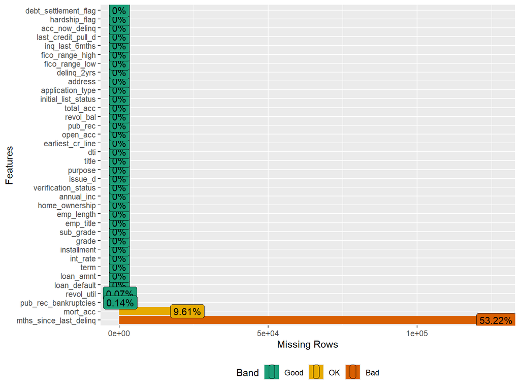

```r
# view missing values
DataExplorer::plot_missing(df)
```

**There are 4 variables (`revol_util`, `pub_rec_bankruptcies`, `mort_acc`, and `mths_since_last_delinq`) that have missing values, only `mths_since_last_delinq` has over 10% missing and `mort_acc` has just shy of 10% missing.**

```r
# view blank values
colSums(df == "", na.rm = TRUE)
```

```
##           loan_default              loan_amnt                   term
##                      0                      0                      0
##               int_rate            installment                  grade
##                      0                      0                      0
##              sub_grade              emp_title             emp_length
##                      0                  13871                  11037
##         home_ownership             annual_inc    verification_status
##                      0                      0                      0
##                issue_d                purpose                  title
##                      0                      0                   1090
##                    dti       earliest_cr_line               open_acc
##                      0                      0                      0
##                pub_rec              revol_bal             revol_util
##                      0                      0                      0
##              total_acc    initial_list_status       application_type
##                      0                      0                      0
##               mort_acc   pub_rec_bankruptcies                address
##                      0                      0                      0
##            delinq_2yrs         fico_range_low        fico_range_high
##                      0                      0                      0
##         inq_last_6mths mths_since_last_delinq     last_credit_pull_d
##                      0                      0                     12
##         acc_now_delinq          hardship_flag   debt_settlement_flag
##                      0                      0                      0
```

**In addition to checking the missing values, we noticed that there are also blank values that may need to be dealt with. Specifically, `emp_title`, `emp_length`, `title`, and `last_credit_pull_d` have blank values that may have meaning, or not.**

## 4.2 Data Visualization

### 4.2.1 Frequency Plots

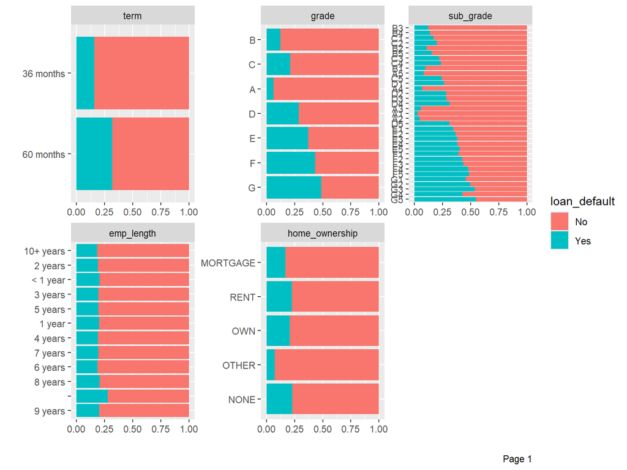

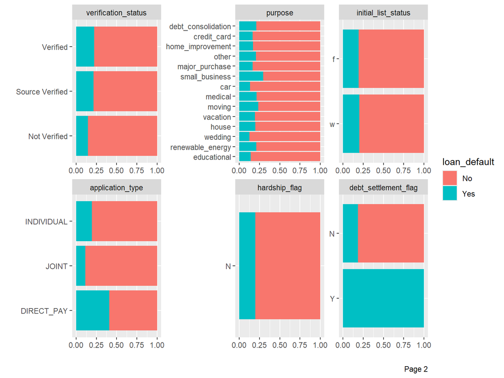

```r
# view frequencies of categorical variables with fewer levels
DataExplorer::plot_bar(df, by="loan_default", nrow=2, ncol=3)
```

**From these bar charts there appears to be some factor levels from a number of the variables that are associated with a higher rate of loan default. The rate of defaulting appears to increase as the `grade` and `sub_grade` of the loan decreases. The similarities in the two variables and their association with loan default suggests to us that it may be wise to drop one of the two variables during cleaning and wrangling. There seems to be greater rates of default for 60 month loans compared to 36 month loans. Loan default seems to be fairly constant relative to `emp_length`, however, when there is a blank value for the variable there seems to be a slight increase. There seems to be a similar pattern for the small business level of the `purpose` variable. There also appears to be a difference for the loan defaulting when `application_type` is direct pay and when `dept_settlement_flag` is yes.**

### 4.2.2 Histogram Plots

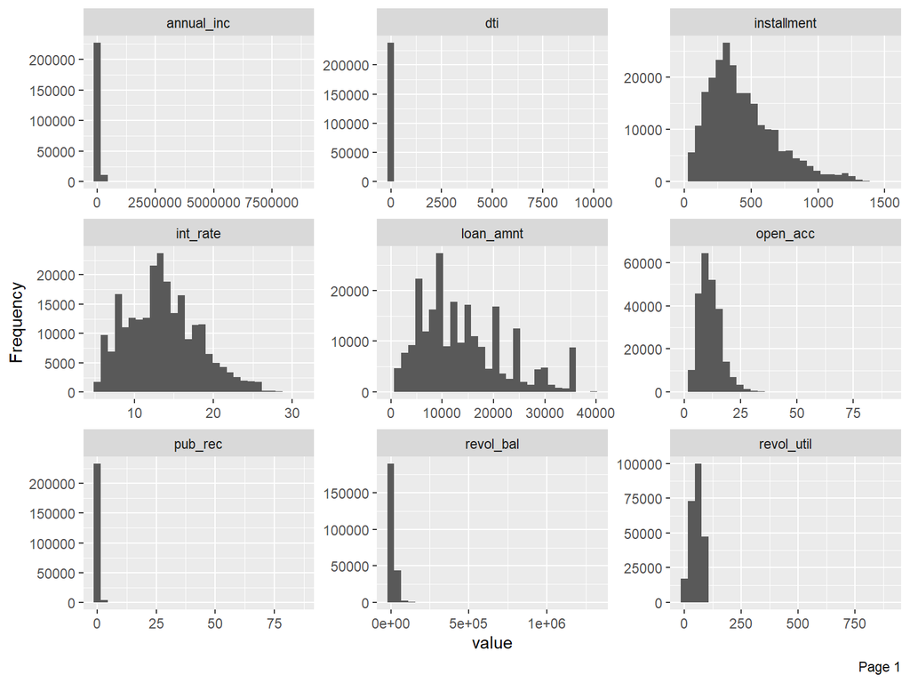

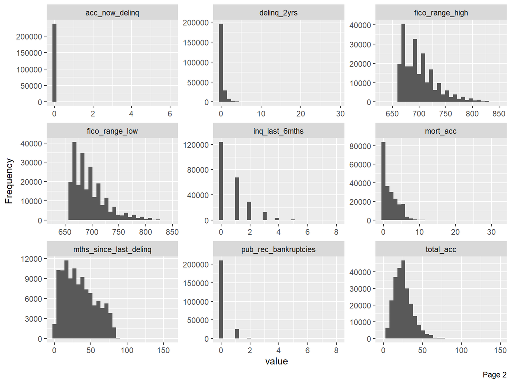

```r
# view distributions of numeric variables
DataExplorer::plot_histogram(df, nrow=3, ncol=3)
```

**The histograms of the numeric variables show all of the variables to have varying degrees of right skews, most being heavily skewed, and some variables that appear to have a multimodal distribution. To address this we will explore transforming or capping some variables and investigate outliers to discern the cause/validity of those observations. There are also some variables that may function better for our purposes as factors instead of numeric.**

### 4.2.3 Correlation Matrix

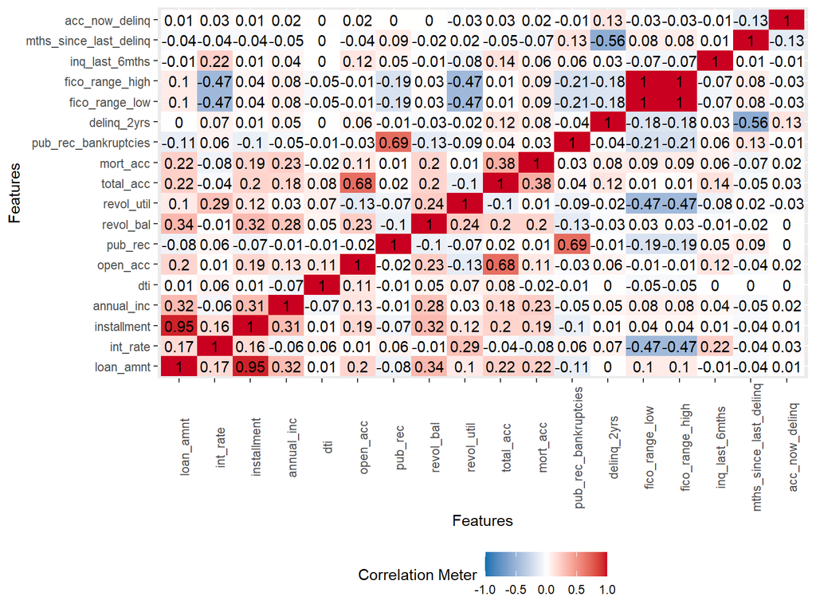

```r
# correlation plot of continuous variables
DataExplorer::plot_correlation(df,
                               type = "continuous",
                               cor_args = list("use" = "pairwise.complete.obs"))
```

**Looking at the correlation matrix, there are a handful of variables that are highly correlated with each other: `installment` and `loan_amnt`, `total_acc` and `open_acc`, `pub_rec` and `pub_rec_bankruptcies`, `delinq_2yrs` and `mths_since_last_delinq`, and `fico_range_low` and `fico_range_high`. We will be looking at these each of these pairings more in depth to assess if we can eliminate any of them or if we can manipulate them together to create another variable with more meaningful information.**

### 4.2.4 Violin Plots

```r
# select numeric columns
num_cols <- df %>%
  dplyr::select(where(is.numeric)) %>%
  names()

# loop through numeric columns and plot
plots <- map(num_cols, function(col) {
  ggplot(df, aes(x = loan_default, y = .data[[col]], fill = loan_default)) +
    geom_violin(trim = FALSE) + # set plots as violin-shaped
    scale_y_log10() + # accounts for skewed values
    labs(title = paste("Distribution of", col, "by Loan Default"),
         y = col, x = "Loan Default") +
    theme_minimal()
})

# display plots
# plots[1:18]
```

**Above is code to create and display violin plots for each numeric variable in the data split by `loan_default`. For the sake of space, the plots are not shown. A look at the plots would show that `int_rate`, `open_acc`, `revol_util`, `fico_range_low`, and `fico_range_high` demonstrate the largest visual differences in distributions for values of “Yes” and “No” of `loan_default`, indicating that these variables may hold some predictive power in predicting `loan_default`in future modeling.**

## 4.3 Data Cleaning

This section includes removing duplicate data, manually setting base levels for factor variables, filling in blank values, combining levels of factor variables, and removing variables from the data all together.

```r
# remove duplicates from data
df <- df %>% distinct()
```

**After exploring the data, we found multiple rows that are duplicated in the data. Likely, these are partners, spouses, or family members included on the same loan application or on a separate, identical loan application. We chose to keep the unique rows in the data and remove all duplicates.**

```r
# set "INDIVIDUAL" as the base level for `application_type`
df$application_type <- fct_relevel(df$application_type, "INDIVIDUAL")

levels(df$application_type)
```

```
## [1] "INDIVIDUAL" "DIRECT_PAY" "JOINT"
```

**We chose to relevel `application_type` so that the highest frequency level, “INDIVIDUAL”, is set as the base level.**

```r
# collapse `purpose` into the top 10 levels in terms of frequency ("other" includes all less frequent levels)
df$purpose <- forcats::fct_collapse(df$purpose, OTHER = c("renewable_energy", "educational", "wedding", "house", "other"))

# set the level with the highest frequency as the base level for `purpose`
df$purpose <- forcats::fct_relevel(df$purpose, names(which.max(table(df$purpose)))) # set base to most frequent level

table(df$purpose)
```

```
##
## debt_consolidation                car        credit_card              OTHER
##             140855               2833              49821              15379
##   home_improvement     major_purchase            medical             moving
##              14388               5284               2536               1706
##     small_business           vacation
##               3437               1437
```

**We chose to relevel `purpose` so that the highest frequency level (“debt_consolidation”) is set as the base level.**

```r
# classify blanks as "unreported" in `emp_length`
df$emp_length <- forcats::fct_recode(df$emp_length, Unreported = "")

table(df$emp_length)
```

```
##
## Unreported   < 1 year     1 year  10+ years    2 years    3 years    4 years
##      11037      19056      15491      75542      21530      19024      14339
##    5 years    6 years    7 years    8 years    9 years
##      15860      12459      12530      11612       9196
```

**In addition to the year values of `emp_length`, there are 11037 blank values. We chose to replace these blank values with “unreported” as an indicator of emptiness.**

```r
# set "10+ years" as the base level for `emp_length`
df$emp_length <- fct_relevel(df$emp_length, "10+ years")

levels(df$emp_length)
```

```
##  [1] "10+ years"  "Unreported" "< 1 year"   "1 year"     "2 years"
##  [6] "3 years"    "4 years"    "5 years"    "6 years"    "7 years"
## [11] "8 years"    "9 years"
```

**We chose to relevel `emp_length` so that the highest frequency level, “10+ years”, is set as the base level.**

```r
# classify "NONE" as "OTHER" in `home_ownership`
df$home_ownership <- forcats::fct_collapse(df$home_ownership, OTHER = c("OTHER", "NONE"))

table(df$home_ownership)
```

```
##
## MORTGAGE    OTHER      OWN     RENT
##   118804       93    22676    96103
```

**The “NONE” and “OTHER” categories of `home_ownership` are extremely sparse compared to `MORTGAGE`, `RENT`, and `OWN. We chose to collapse “OTHER” and “NONE” into the “OTHER” category to reduce the number of levels and mitigate data sparsity.**

```r
# remove `hardship_flag`
df <- df %>% dplyr::select(-hardship_flag)
```

**We chose to remove `hardship_flag` from the data since it is a constant column across all observations, so it contains no predictive power.**

```r
# remove `installment`
df <- df %>% dplyr::select(-installment)
```

**We chose to remove `installment` from the data since it is nearly perfectly collinear with `loan_amnt`, `loan_amnt` seems more fundamental than `installment`, and `installment` could most likely be calculated using `lona_amnt`, `term`, and `int_rate`.**

```r
# remove `title`
df <- df %>% dplyr::select(-title)
```

**We chose to remove `title` from the data since it seems to be a user-entered, more granular (31659 levels > 14 levels), and often repetitive version of `purpose`.**

## 4.4 Data Wrangling

This section includes recategorizing date variables into meaningful time variables, collapsing factor variables, binning numeric variables, numeric to factor conversions, and feature extraction.

```r
# recategorizing `issue_d` into years since
df$issue_d_date <- my(df$issue_d)
df$issue_d_years_since <- year(Sys.Date()) - year(df$issue_d_date) # difference between current year and year of issue date

# recategorizing `issue_d` into months of the year
# df$issue_d_months <- substr(df$issue_d, 0, 3) # pull out 3-letter abbreviation of month (e.g. "Apr")

# table(df$issue_d_months)

# remove `issue_d` and `issue_d_date`
df <- df %>% dplyr::select(-issue_d, -issue_d_date)
```

**`issue_d` has 115 different combinations of months and years spanning from June 2007 to December 2016. To reduce this variable to something more interpretable, we chose to convert the issue date to a “years since” idea, reducing the total levels and assuming the month of loan issue has little to no significance relative to year. Depending on the performance of `issue_d_years_since` in the modeling phase, we may choose to backtrack and convert the issue date to just the month of the issue date instead, reducing the total levels to 12 and assuming the year of the loan issue has little to no significance relative to month. This stems from the idea that lenders may need to meet a certain loan amount/quantity quota for quarters or seasons within a year, sparking a change of behavior when approving loans.**

```r
# log transforming `open_acc`
# df$open_acc_log <- log1p(df$open_acc)

# capping `open_acc`
# quantile(df$open_acc, probs = seq(0.9, 1, 0.001)) # print quantiles to visually identify cutoffs
# cap_value <- quantile(df$open_acc, 0.998) # assign value at given quantile
# df$open_acc_cap <- ifelse(df$open_acc > cap_value, cap_value, df$open_acc)

# combining `open_acc` into 10 semi-equal width bins
df$open_acc_bins <- cut(
  df$open_acc,
  breaks = quantile(df$open_acc, probs = seq(0, 1, 0.1)),
  include.lowest = TRUE
)

table(df$open_acc_bins)
```

```
##
##   [0,6]   (6,7]   (7,8]   (8,9]  (9,10] (10,12] (12,13] (13,15] (15,18] (18,90]
##   36934   18889   20980   22063   21268   37012   15000   23031   21152   21347
```

**`open_acc` is very right-skewed with a couple large outliers. We chose to bin `open_acc` into 10 relatively equal-width bins to reduce the total levels and retain interpretability. Depending on the performance of `open_acc_bins` in the modeling phase, we may choose to backtrack and either perform a log1p (accounting for values of “0”) transformation on `open_acc` to make the distribution close to normal and more symmetric, or cap `open_acc` to the 99.8th percentile to limit the influence of the large outliers on future analysis.**

```r
# recategorizing `earliest_cr_line` into years since
df$earliest_cr_line_date <- my(df$earliest_cr_line)
df$earliest_cr_line_years_since <- year(Sys.Date()) - year(df$earliest_cr_line_date) # difference between current year and year of earliest credit line

# combining `earliest_cr_line_years_since` into 10 semi-equal width bins
df$earliest_cr_line_bins <- cut(
  df$earliest_cr_line_years_since,
  breaks = quantile(df$earliest_cr_line_years_since, probs = seq(0, 1, 0.1)),
  include.lowest = TRUE
)

table(df$earliest_cr_line_bins)
```

```
##
## [12,19] (19,21] (21,23] (23,24] (24,26] (26,27] (27,30] (30,32] (32,37] (37,75]
##   26042   23015   29889   17367   33638   13639   32536   16541   23575   21434
```

```r
# remove `earliest_cr_line` and `earliest_cr_line_date`
df <- df %>% dplyr::select(-earliest_cr_line, -earliest_cr_line_date, -earliest_cr_line_years_since)
```

**`earliest_cr_line` has 659 different combinations of months and years spanning from November 1950 to October 2013. To reduce this variable to something more interpretable, we chose to convert the issue date to a “years since” idea, reducing the total levels and assuming the month of earliest credit line has little to no significance relative to year. Additionally, we chose to bin these “years since” counts into 10 relatively equal-width bins to again reduce the total levels and retain interpretability.**

```r
# convert `address` from factor to character
df$address <- as.character(df$address)

# pull out `zip_code` from `address`
# df$zip_code <- factor(substr(df$address, nchar(df$address) - 4, nchar(df$address))) # zip code is located in the last 5 indexes

# table(df$zip_code)

# pull out `territory` from `address`
df$territory <- factor(substr(df$address, nchar(df$address) - 7, nchar(df$address) - 6)) # territory is located within the indexes (-7,-6)

# remove `address`
df <- df %>% dplyr::select(-address)
```

**`address` is made up of 99.58% unique values. In order to treat `address` as a factor with a reasonable number of levels, we chose to pull out the territories from each address and use `territory` as a substitute for location. In addition to the 50 U.S. states, “DC” (District of Columbia), “AA” (Armed Forces America), “AE” (Armed Forces Europe, Middle East, Africa, Canada), and “AP” (Armed Forces Pacific) are included as territories in the data. We also considered pulling out zip code as a more granular location variable, but there seems to be a data entry error as only 10 unique zip codes are found in the data despite there being 54 territories.**

```r
# recode `delinq_2yrs` into 4 levels: "0", "1", "2", "3+"
df$delinq_2yrs <- forcats::fct_collapse(
  df$delinq_2yrs %>% as.character(),
  "0" = "0",
  "1" = "1",
  "2" = "2",
  "3+" = as.character(3:max(df$delinq_2yrs))) # range from 3 to the max value of the variable

# reorder levels of `delinq_2yrs`
df$delinq_2yrs <- forcats::fct_relevel(df$delinq_2yrs, "0", "1", "2", "3+")

table(df$delinq_2yrs)
```

```
##
##      0      1      2     3+
## 195575  28641   8097   5363
```

**`delinq_2yrs` is zero-dominated and thus right-skewed. To combat this, we chose to convert `delinq_2yrs` to factor and collapse the categories into 4 levels: “0”, “1”, “2”, and “3+”. We did this to reduce the number of levels, mitigate data sparsity, and classify large values of `delinq_2yrs` as equal.**

```r
# recode `inq_last_6mths` into 3 levels: "0", "1", "2+"
df$inq_last_6mths <- forcats::fct_collapse(
  df$inq_last_6mths %>% as.character(),
  "0" = "0",
  "1" = "1",
  "2+" = as.character(2:max(df$inq_last_6mths))) # range from 2 to the max value of the variable

# reorder the levels of `inq_last_6mths`
df$inq_last_6mths <- forcats::fct_relevel(df$inq_last_6mths, "0", "1", "2+")

table(df$inq_last_6mths)
```

```
##
##      0      1     2+
## 123428  67507  46741
```

```r
# recode `acc_now_delinq` into 2 levels: "0", "1+"
df$acc_now_delinq <- forcats::fct_collapse(
  df$acc_now_delinq %>% as.character(),
  "0" = "0",
  "1+" = as.character(1:max(as.numeric(df$acc_now_delinq))))  # range from 1 to the max value of the variable

# reorder the levels of `acc_now_delinq`
df$acc_now_delinq <- forcats::fct_relevel(df$acc_now_delinq, "0", "1+")

table(df$acc_now_delinq)
```

```
##
##      0     1+
## 236743    933
```

## 4.5 Feature Engineering

This section includes slicing variables, performing log transformations, capping numeric variables, creating difference variables, creating ratio features, binning numeric variables, removing observations, imputing missing values, creating average variables, collapsing factor variables, and category mapping.

```r
# remove `grade`
df <- df %>% dplyr::select(-grade)

# remove lettering from `sub_grade`
# df$sub_grade_num <- as.numeric(gsub("[A-G]", "", df$sub_grade)) # substitute all letters A through G with empty space and treat resulting value as continuous

# remove `sub_grade`
# df <- df %>% dplyr::select(-sub_grade)
```

**`grade` has 7 levels with values of “A” through “G”. `sub_grade` adds a number from 1 to 5 on top of these alphabetical values as a more granular risk rating within each grade. We chose to drop `grade` as the values of `grade` are included within `sub_grade`, therefore all of the predictive power within `grade` is theoretically captured by the more granular `sub_grade`. Depending on the performance of `grade` in the modeling phase, we may choose to backtrack and remove the alphabetical values from `sub_grade` as they are already included in `grade`, allowing `sub_grade_num` to be treated as continuous.**

```r
# log transforming `annual_inc`
df$annual_inc_log <- log1p(df$annual_inc)

# capping `annual_inc`
# quantile(df$annual_inc, probs = seq(0.9, 1, 0.001)) # print quantiles to visually identify cutoffs
# cap_value <- quantile(df$annual_inc, 0.995) # assign value of given quantile
# df$annual_inc_cap <- ifelse(df$annual_inc > cap_value, cap_value, df$annual_inc)

# remove `annual_inc`
df <- df %>% dplyr::select(-annual_inc)
```

**`annual_inc` is severely right-skewed with many large outliers. We chose to perform a log transformation on `annual_inc` to make the distribution close to normal and more symmetric. Depending on the performance of `annual_inc_log` in the modeling phase, we may choose to backtrack and cap `annual_inc` to the 99.5th percentile instead to limit the influence of the extreme outliers on future analysis.**

```r
# remove observation with value of "9999.00" for `dti`
df <- df[-96957, ]

# log transforming `dti`
# df$dti_log <- log1p(df$dti)

# capping `dti`
# quantile(df$dti, probs = seq(0.9, 1, 0.001)) # print quantiles to visually identify cutoffs
cap_value <- quantile(df$dti, 0.999) # assign value of given quantile
df$dti_cap <- ifelse(df$dti > cap_value, cap_value, df$dti)

# remove `dti`
df <- df %>% dplyr::select(-dti)
```

**`dti` is severely right-skewed with a couple large outliers. We chose to remove observation number 96957 with a value of “9999.00” because this value corresponds to infinity due to a reported value of 0 for `annaul_inc`. Additionally, we chose to cap `dti` to the 99.9th percentile to limit the influence of the extreme outliers on future analysis. Depending on the performance of `dti_cap` in the modeling phase, we may choose to backtrack and perform a log1p (accounting for values of “0”) transformation on `dti` to make the distribution close to normal and more symmetric.**

```r
# log transforming `revol_bal`
df$revol_bal_log <- log1p(df$revol_bal)

# capping `revol_bal`
# quantile(df$revol_bal, probs = seq(0.9, 1, 0.001)) # print quantiles to visually identify cutoffs
# cap_value <- quantile(df$revol_bal, 0.996) # assign value of given quantile
# df$revol_bal_cap <- ifelse(df$revol_bal > cap_value, cap_value, df$revol_bal)

# remove `revol_bal`
df <- df %>% dplyr::select(-revol_bal)
```

**`revol_bal` is severely right-skewed with many large outliers. We chose to perform a log transformation on `revol_bal` to make the distribution close to normal and more symmetric. Depending on the performance of `revol_bal_log` in the modeling phase, we may choose to backtrack and cap `revol_bal` to the 99.6th percentile instead to limit the influence of the extreme outliers on future analysis.**

```r
# impute missing values of `pub_rec_bankruptcies` as 0
df$pub_rec_bankruptcies <- ifelse(is.na(df$pub_rec_bankruptcies), 0, df$pub_rec_bankruptcies)

# create `pub_rec_non_bankruptcies` as difference between `pub_rec` and `pub_rec_bankruptcies`
df$pub_rec_non_bankruptcies <- df$pub_rec - df$pub_rec_bankruptcies

# recode `pub_rec_non_bankruptcies` into 2 levels: "0", "1+"
df$pub_rec_non_bankruptcies <- forcats::fct_collapse(
  df$pub_rec_non_bankruptcies %>% as.character(),
  "0" = "0",
  "1+"= as.character(1:max(df$pub_rec_non_bankruptcies))) # range from 1 to the max value of the variable

table(df$pub_rec_non_bankruptcies)
```

```
##
##      0     1+
## 228511   9164
```

```r
# recode `pub_rec_bankruptcies` into 3 levels: "0", "1", "2+"
df$pub_rec_bankruptcies <- forcats::fct_collapse(
  df$pub_rec_bankruptcies %>% as.character(),
  "0" = "0",
  "1" = "1",
  "2+" = as.character(2:max(df$pub_rec_bankruptcies))) # range from 2 to the max value of the variable

# remove `pub_rec`
df <- df %>% dplyr::select(-pub_rec)

table(df$pub_rec_bankruptcies)
```

```
##
##      0      1     2+
## 210717  25571   1387
```

**There are 336 missing values in `pub_rec_bankruptcies`. We chose to impute these missing values with zeroes as the majority of the missing values in `pub_rec_bankruptcies` corresponded to a value of 0 for `pub_rec`, and `pub_rec` by nature includes `pub_rec_bankruptcies`. We then chose to create `pub_rec_non_bankruptcies` as the difference between `pub_rec` and `pub_rec_bankruptcies` to replace `pub_rec` and accommodate for double-counting bankruptcies and any multicollinearity between `pub_rec` and `pub_rec_bankruptcies`. `pub_rec_non_bankruptcies` is zero-dominated and thus very right-skewed. To combat this, we chose to convert `pub_rec_non_bankruptcies` to factor and collapse the categories into 2 levels: “0” and “1+”. Additionally, `pub_rec_bankruptcies` is zero-dominated and thus very right-skewed. To combat this, we chose to convert `pub_rec_bankruptcies` to factor and collapse the categories into 3 levels: “0”, “1”, and “2+”. We did this to reduce the number of levels and mitigate data sparsity.**

```r
# create `closed_acc` as difference between `total_acc` and `open_acc`
df$closed_acc <- df$total_acc - df$open_acc

# log transforming `closed_acc`
# df$closed_acc_log <- log1p(df$closed_acc)

# capping `closed_acc`
# quantile(df$closed_acc, probs = seq(0.9, 1, 0.001)) # print quantiles to visually identify cutoffs
# cap_value <- quantile(df$closed_acc, 0.998) # assign value of given quantile
# df$closed_acc_cap <- ifelse(df$closed_acc > cap_value, cap_value, df$closed_acc)

# combining `closed_acc` into 10 semi-equal width bins
df$closed_acc_bins <- cut(
  df$closed_acc,
  breaks = quantile(df$closed_acc, probs = seq(0, 1, 0.1)),
  include.lowest = TRUE
)

# remove `open_acc`, `total_acc`, and `closed_acc`
df <- df %>% dplyr::select(-open_acc, -total_acc, -closed_acc)

table(df$closed_acc_bins)
```

```
##
##    [0,4]    (4,6]    (6,8]   (8,10]  (10,13]  (13,15]  (15,18]  (18,21]
##    31619    20025    22116    22294    32268    19549    25120    19529
##  (21,26] (26,110]
##    21558    23597
```

```r
# impute missing values of `revol_util` as 0
df$revol_util <- ifelse(is.na(df$revol_util), 0, df$revol_util)

# capping `revol_util`
# quantile(df$revol_util, probs = seq(0.9, 1, 0.001)) # print quantiles to visually identify cutoffs
cap_value <- quantile(df$revol_util, 0.999) # assign value of given quantile
df$revol_util_cap <- ifelse(df$revol_util > cap_value, cap_value, df$revol_util)

# remove `revol_util`
df <- df %>% dplyr::select(-revol_util)
```

**There are 177 missing values in `revol_util`. We chose to impute these missing values with zeroes as the majority of the missing values in `revol_util` corresponded to a value of 0 for `revol_bal`. Likewise, the majority of the values of 0 in `revol_util` corresponded to a value of 0 for `revol_bal` as well, so it made logical sense to treat the missing values as zeroes. `revol_util` is also very right-skewed with a couple large outliers. We chose to cap `revol_util` to the 99.9th percentile to limit the influence of the large outliers on future analysis.**

```r
# calculate average of FICO score range
df$fico_range_avg <- (df$fico_range_high + df$fico_range_low) / 2

# remove `fico_range_low` and `fico_range_high`
df <- df %>% dplyr::select(-fico_range_low, -fico_range_high)
```

**Each observation has a value for `fico_range_low` and `fico_range_high` with a difference of either 4 or 5. To reduce the two perfectly correlated variables into one, we chose to take the average of the range.**

```r
# recode `mths_since_last_delinq` as factor
df$mths_since_last_delinq <- factor(df$mths_since_last_delinq)

# impute missing values of `mths_since_last_delinq as "Never"
df$mths_since_last_delinq <- ifelse(is.na(df$mths_since_last_delinq), "Never", df$mths_since_last_delinq)

# recode `mths_since_last_delinq` to year ranges from character-converted months
df$yrs_since_last_delinq <- df$mths_since_last_delinq %>%
  as.character() %>%
  fct_collapse(
    "Never" = "Never",
    "<1yr" = as.character(0:11),
    "1-2yr" = as.character(12:23),
    "2-3yr" = as.character(24:35),
    "3-4yr" = as.character(36:47),
    "4-5yr" = as.character(48:59),
    "5-6yr" = as.character(60:71),
    ">6yr" = as.character(72:max(as.numeric(df$mths_since_last_delinq[df$mths_since_last_delinq != "Never"])))) # range from 72 to the max value of the variable

# reorder the levels of `yrs_since_last_delinq`
df$yrs_since_last_delinq <- forcats::fct_relevel(df$yrs_since_last_delinq, "Never", "<1yr", "1-2yr", "2-3yr", "3-4yr", "4-5yr", "5-6yr", ">6yr")

# remove `mths_since_last_delinq`
df <- df %>% dplyr::select(-mths_since_last_delinq)

table(df$yrs_since_last_delinq)
```

```
##
##  Never   <1yr  1-2yr  2-3yr  3-4yr  4-5yr  5-6yr   >6yr
## 126474  16504  23278  20499  18110  12724  11049   9037
```

**There are 126,474 missing values in `mths_since_last_delinq`. We chose to impute these missing values with “Never” as the missing values in `mths_since_last_delinq` correspond to a loan applicant never having a delinquency. Additionally, we chose to recode `mths_since_last_delinq` into year ranges to reduce the number of levels and mitigate data sparsity; grouping all values greater than 6 years into one level was done as an attempt to create semi-equally-weighted levels and resolve data sparsity.**

```r
# recategorizing `last_credit_pull_d` into years since
df$last_credit_pull_d_date <- my(df$last_credit_pull_d)
df$last_credit_pull_d_years_since <- year(Sys.Date()) - year(df$last_credit_pull_d_date) # difference between current year and year of issue date

# impute blank values of `last_credit_pull_d_years_since as "Never"
df$last_credit_pull_d_years_since <- factor(ifelse(is.na(df$last_credit_pull_d_years_since), "Never", df$last_credit_pull_d_years_since))

# regroup `last_credit_pull_d_years_since` to year ranges
df$last_credit_pull_d_years_since <- df$last_credit_pull_d_years_since %>%
  as.character() %>%
  fct_collapse(
    "Never" = "Never",
    "6" = "6",
    "7" = "7",
    "8" = "8",
    "9" = "9",
    "10+" = as.character(10:18)) # range from 10 to 18

# reorder the levels of `last_credit_pull_d_years_since`
df$last_credit_pull_d_years_since <- forcats::fct_relevel(df$last_credit_pull_d_years_since, "Never", "6", "7", "8", "9", "10+")

# remove `last_credit_pull_d` and `last_credit_pull_d_date`
df <- df %>% dplyr::select(-last_credit_pull_d, -last_credit_pull_d_date)

table(df$last_credit_pull_d_years_since)
```

```
##
## Never     6     7     8     9   10+
##    12 75619 48406 37213 50380 26045
```

**In addition to the date values of `last_credit_pull_d`, there are 12 blank values. We chose to replace these blank values with “Never” as an indicator of a loan applicant never having their credit pulled. `last_credit_pull_d` has 137 different combinations of months and years spanning from June 2007 to March 2019. To reduce this variable to something more interpretable, we chose to convert the issue date to a “years since” idea, reducing the total levels and assuming the month of last credit pull has little to no significance relative to year. Additionally, we chose to recode `last_credit_pull_d_years_since` into year ranges to again reduce the number of levels and mitigate data sparsity.**

```r
# clean `emp_title`
df$emp_title_clean <- df$emp_title %>%
  as.character() %>% # convert to character
  str_trim() %>% # remove all trailing or leading spaces
  str_to_lower() # convert all letters to lowercase

# count the alphabetical, non-modifier words in `emp_title_clean`
word_counts <- df %>%
  select(emp_title_clean) %>%
  unnest_tokens(word, emp_title_clean) %>% # split into words
  filter(!word %in% stop_words$word, # remove common prepositions, conjunctions, and modifiers
         str_detect(word, "[a-z]")) %>% # keep only letters
  count(word, sort = TRUE)

# grab the 200 most common words
common_words <- head(word_counts, 200)

# group `emp_title` into broad categories based on the most common words by pattern matching using regex()
df$emp_title_group <- case_when(
  str_detect(df$emp_title_clean, regex("teach|school|professor|instructor|principal|university|education|college", ignore_case = TRUE)) ~ "Education",
  str_detect(df$emp_title_clean, regex("nurse|rn|clinical|therapist|physician|healthcare|dental|pharmacy|technologist|nursing", ignore_case = TRUE)) ~ "Healthcare",
  str_detect(df$emp_title_clean, regex("driver|truck|mechanic|transportation|bus|logistics|carrier", ignore_case = TRUE)) ~ "Transportation",
  str_detect(df$emp_title_clean, regex("manager|president|vp|vice|chief|director|supervisor|leader|executive|superintendent", ignore_case = TRUE)) ~ "Management",
  str_detect(df$emp_title_clean, regex("account|accountant|accounting|accounts|banker|finance|financial|controller|auditor|credit|loan|insurance|mortgage|underwriter|claims|tax", ignore_case = TRUE)) ~ "Business",
  str_detect(df$emp_title_clean, regex("sales|sale|rep|representative|customer|client|advisor|agent|marketing|store|associate", ignore_case = TRUE)) ~ "Sales",
  str_detect(df$emp_title_clean, regex("clerk|coordinator|secretary|administrative|admin|office|support|assistant|asst", ignore_case = TRUE)) ~ "Administration",
  str_detect(df$emp_title_clean, regex("engineer|engineering|software|programmer|developer|technician|technical|tech|technology|network|data|it|system|computer|design|designer", ignore_case = TRUE)) ~ "Tech",
  str_detect(df$emp_title_clean, regex("police|sheriff|fire|sergeant|correctional|army|military|navy|federal|public|postal|government", ignore_case = TRUE)) ~ "Public/Government",
  str_detect(df$emp_title_clean, regex("construction|electrician|foreman|mechanic|maintenance|equipment|operator|machin|labor|inspector|mech", ignore_case = TRUE)) ~ "Trades",
  str_detect(df$emp_title_clean, regex("attorney|paralegal|legal|compliance", ignore_case = TRUE)) ~ "Legal",
  str_detect(df$emp_title_clean, regex("owner|self|llc|corp|corporation|company|associates|llp", ignore_case = TRUE)) ~ "Self-Employed",
  TRUE ~ "Other"
)

# remove `emp_title` and `emp_title_clean`
df <- df %>% dplyr::select(-emp_title, -emp_title_clean)

table(df$emp_title_group)
```

```
##
##    Administration          Business         Education        Healthcare
##             12839              8298             11236             13504
##             Legal        Management             Other Public/Government
##               653             44660             88823              2969
##             Sales     Self-Employed              Tech            Trades
##              8879              5727             26152              5242
##    Transportation
##              8693
```

**`emp_title` is another user-entered variable with 112,646 different unique values. We chose to combine values containing the most common words/strings into a much smaller set of broad categories to hopefully gain predictive power. Disclaimer: ChatGPT was leveraged to help with the syntax for counting words and for the tediousness of mapping words to categories.**

```r
# set the level with the highest frequency as the base level for `emp_title_group`
df$emp_title_group <- forcats::fct_relevel(df$emp_title_group, names(which.max(table(df$emp_title_group))))

levels(df$emp_title_group)
```

```
##  [1] "Other"             "Administration"    "Business"
##  [4] "Education"         "Healthcare"        "Legal"
##  [7] "Management"        "Public/Government" "Sales"
## [10] "Self-Employed"     "Tech"              "Trades"
## [13] "Transportation"
```

**We chose to relevel `emp_title_group` so that the highest frequency level (“Other”) is set as the base level.**

```r
# recode `term` to years for consistency, and remove leading spaces
df$term <- as.factor(ifelse(df$term == " 36 months", "3 Years", "5 Years"))

table(df$term)
```

```
##
## 3 Years 5 Years
##  181465   56210
```

**We chose to rename the values of `term` from months to years to be consistent with our general feature engineering approach for time variables. Additionally, there was a leading space in front of the original values, so we removed it.**

```r
# create missing value indicator of `mort_acc`
df$mort_acc_NA <- ifelse(is.na(df$mort_acc), 1, 0)

# impute missing values of `mort_acc` as median of `home_ownership` groupings
df <- df %>%
  group_by(home_ownership) %>%
  mutate(mort_acc = ifelse(is.na(mort_acc), median(mort_acc, na.rm = TRUE), mort_acc)) %>% # impute median of `mort_acc` for each group
  ungroup()

# recode `mort_acc` into 5 levels
df$mort_acc <- forcats::fct_collapse(
  df$mort_acc %>% as.character(),
  "0" = "0",
  "1" = "1",
  "2" = "2",
  "3-4" = as.character(3:4),
  "5+" = as.character(5:max(df$mort_acc))) # range from 72 to the max value of the variable

# reorder levels of `mort_acc`
df$mort_acc <- forcats::fct_relevel(df$mort_acc, "0", "1", "2", "3-4", "5+")

table(df$mort_acc)
```

```
##
##     0     1     2   3-4    5+
## 94716 38285 39989 39640 25045
```

**There are 22854 missing values in `mort_acc`. We chose to impute these missing values with the median of the given level of `home_ownership` for each corresponding observation. Since `mort_acc` seems to logically be related to `home_ownership` in some fashion, we chose to impute using `home_ownership` rather than just simple imputation. `mort_acc` is zero-dominated and thus very right-skewed. To combat this, we chose to convert `mort_acc` to factor and collapse the categories into 5 levels: “0”, “1”, “2”, “3-4”, and “5+”. We did this to avoid issues with skew, mitigate data sparsity, and classify larger values of `mort_acc` as equal.**

## 4.6 Additional Comments

- **We have also considered probable two-variable interactions within the data, however, we have not added any into the data frame yet. Depending on the types of predictive models we fit later on, we intend to either add in interactions (e.g. logistic regression) or account for implied interactions (e.g. random forest). Below are four two-variable interactions in the data that we believe would logically have predictive power.**

```r
# display a list of variables in the data
# colnames(df)

# create a set of probable two-variable interactions in the data
# df <- df %>%
#   mutate(int_mort_home = paste0(home_ownership, "_", mort_acc))
#
# df <- df %>%
#   mutate(int_dti_income = dti_cap * annual_inc_log)
#
# df <- df %>%
#   mutate(int_fico_loan = fico_range_avg * loan_amnt)
#
# df <- df %>%
#   mutate(int_loan_income = loan_amnt * annual_inc_log)
```

- **In our EDA, we did not consider the predictive power or significance of variables by fitting any form of logistic regression model. We chose to rely on logic, domain knowledge, and visual insights in making our initial data cleaning, dimension reduction, and encoding decisions. Therefore, we acknowledge there may be a few variables still present in the data that will prove to be uninformative and lack predictive power upon model fitting.**

# 5 Save as RDS

```r
saveRDS(df, file = "group9A_Berry-Cradduck_train.rds")
```